# PCFL: Week 4 wrap-up

### Last week’s games

| away_team | awaypoints | home_team | homepoints |
| --- | --- | --- | --- |
| Captain Clairvoyant | 105.64 | First Timers The FTs | 141.24 |
| The G.O.A.T. | 94.80 | KC Gophers | 90.35 |
| Southern Sharks | 122.80 | Pigskin on the Gridiron | 99.54 |
| Middle Earth Hangry Hobbits | 114.90 | Athens Team Sasquatch | 116.37 |
| Jumpin’ Jaheims | 110.72 | Georgia Peanuts | 124.70 |

The premier matchup last week was the faceoff between Captain Clairvoyant and the First Timers…and it wasn’t particularly close. Brian’s algorithm failed him, and the FT’s walked away with an easy victory (and the highest point total of the week). We now have NO undefeated teams.

In other matchups, Robbie’s Sasquatch squeaked out a victory over Scott’s Hobbits in a matchup of (probably) mythical creatures. The *tough luck loss* of the week goes to Scott’s team in this one, as 115 points just weren’t enough. The *someone had to win* game of the week goes to Jacob and Christine’s matchup, where the G.O.A.T. didn’t quite live up to it’s billing but still got the W.

Here’s last week’s **10 best performing players.** The bench variable shows whether they got left on the bench or not.

| name | points | fullname | bench |
| --- | --- | --- | --- |
| Joe Mixon | 39.10 | KC Gophers | 0 |
| Dak Prescott | 37.28 | Southern Sharks | 1 |
| Odell Beckham Jr. | 35.90 | First Timers The FTs | 0 |
| George Kittle | 32.60 | Middle Earth Hangry Hobbits | 0 |
| Tom Brady | 32.46 | Pigskin on the Gridiron | 0 |
| Aaron Rodgers | 29.58 | Captain Clairvoyant | 1 |
| Dalvin Cook | 27.60 | Georgia Peanuts | 0 |
| Amari Cooper | 27.40 | Captain Clairvoyant | 0 |
| DJ Chark Jr. | 25.50 | Georgia Peanuts | 1 |
| Josh Allen | 25.42 | Jumpin’ Jaheims | 0 |

Sarah left Dak Prescott’s 37 points on the bench, and Brian could have probably used Aaron Rodgers in his starting lineup. Odell Beckham had a monster week, and George Kittle made this former Hawkeye proud (and a top 5 points performance for a TE is notable).

There were 17 players added last week. Which was the **best new addition**?

| add_date | name | points | fullname |
| --- | --- | --- | --- |
| 2020-10-02 | Randy Bullock | 17.00 | Georgia Peanuts |
| 2020-10-01 | Joe Burrow | 15.10 | KC Gophers |
| 2020-10-02 | Eagles D/ST | 14.00 | Athens Team Sasquatch |
| 2020-09-30 | Nick Foles | 11.86 | Georgia Peanuts |
| 2020-10-02 | Jared Goff | 11.70 | The G.O.A.T. |
| 2020-09-30 | Tee Higgins | 11.00 | Georgia Peanuts |
| 2020-10-01 | T.J. Hockenson | 9.90 | Pigskin on the Gridiron |
| 2020-09-30 | Hunter Renfrow | 9.00 | Athens Team Sasquatch |
| 2020-10-01 | Jason Myers | 9.00 | Pigskin on the Gridiron |
| 2020-09-30 | Myles Gaskin | 7.70 | Southern Sharks |
| 2020-09-30 | Mason Crosby | 7.00 | Captain Clairvoyant |
| 2020-10-03 | Marquez Valdes-Scantling | 6.50 | Georgia Peanuts |
| 2020-10-03 | Joey Slye | 6.00 | Athens Team Sasquatch |
| 2020-10-04 | Panthers D/ST | 5.00 | Southern Sharks |
| 2020-10-01 | Cordarrelle Patterson | 4.25 | KC Gophers |
| 2020-10-04 | Brian Hill | 3.30 | Pigskin on the Gridiron |
| 2020-09-30 | Cardinals D/ST | -2.00 | Georgia Peanuts |

Among the top additions of the week, some QBs make the list (Burrow, Foles, and Goff), though with modest numbers for their postiion. The Eagles D was a nice add by Robbie.

Who should have been **left on the bench** this week–the lowest points scored by starters?

| name | points | fullname |
| --- | --- | --- |
| Cardinals D/ST | -2 | Georgia Peanuts |
| Brandin Cooks | 0 | The G.O.A.T. |
| Raheem Mostert | 0 | KC Gophers |
| Derrick Henry | 0 | Captain Clairvoyant |
| Calvin Ridley | 0 | Athens Team Sasquatch |
| Steelers D/ST | 0 | Athens Team Sasquatch |
| Diontae Johnson | 0 | Pigskin on the Gridiron |

Well, trying a new defense didn’t quite work out for me.

Who won the **best scoring bench** award last week?

| fullname | points |
| --- | --- |
| Southern Sharks | 103.08 |
| First Timers The FTs | 79.92 |
| The G.O.A.T. | 79.75 |
| Captain Clairvoyant | 77.38 |
| Pigskin on the Gridiron | 72.69 |
| Georgia Peanuts | 70.56 |
| Jumpin’ Jaheims | 69.40 |
| Athens Team Sasquatch | 50.80 |
| Middle Earth Hangry Hobbits | 24.00 |
| KC Gophers | 12.80 |

Sarah walked away with the deepest bench for the second week in a row.

### League standings and season stats

Here’s a look at our current standings

| fullname | division | W | L | points_scored | points_allowed | points_rank | playoff_rank |
| --- | --- | --- | --- | --- | --- | --- | --- |
| First Timers The FTs | Hot Dish | 3 | 1 | 554.56 | 460.02 | 1 | 1 |
| Captain Clairvoyant | Grits | 3 | 1 | 523.32 | 447.00 | 2 | 2 |
| The G.O.A.T. | Grits | 3 | 1 | 480.59 | 449.95 | 3 | 3 |
| Athens Team Sasquatch | Grits | 3 | 1 | 467.66 | 459.82 | 6 | 4 |
| Georgia Peanuts | Hot Dish | 2 | 2 | 471.82 | 472.97 | 4 | 5 |
| Southern Sharks | Hot Dish | 2 | 2 | 469.64 | 463.47 | 5 | 6 |
| KC Gophers | Hot Dish | 2 | 2 | 409.93 | 444.58 | 9 | 7 |
| Middle Earth Hangry Hobbits | Hot Dish | 1 | 3 | 437.26 | 454.13 | 7 | 8 |
| Pigskin on the Gridiron | Grits | 1 | 3 | 407.68 | 476.98 | 10 | 9 |
| Jumpin’ Jaheims | Grits | 0 | 4 | 432.44 | 525.98 | 8 | 10 |

Here’s our current awards leaders from these standings:

- Yellow shirt (most points): First Timers
- D-FENCE (least points allowed): KC Gophers
- Tough luck (points rank - playoff rank): Jumpin’ Jaheims
- Lucky ducks (playoff rank - points rank): KC Gophers & Team Sasquatch

Here’s a list of the **top five scoring performances** so far this season.

| fullname | week | points_scored | result |
| --- | --- | --- | --- |
| First Timers The FTs | 2 | 171.28 | W |
| Captain Clairvoyant | 3 | 150.32 | W |
| First Timers The FTs | 4 | 141.24 | W |
| The G.O.A.T. | 1 | 139.20 | W |
| Athens Team Sasquatch | 1 | 138.55 | W |

The First Timers now own 2 of the 3 top spots on this one.

Lastly, here’s a look at the **points trendline** for each team.

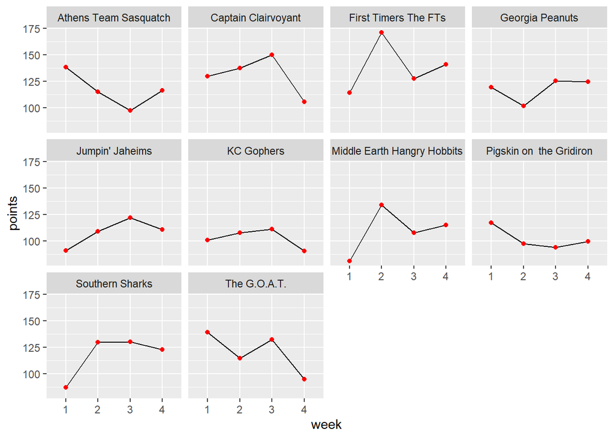

## Next week’s games

Here’s a quick summary of next week’s matchups:

| week | away_team | away_points | home_team | home_points | range |
| --- | --- | --- | --- | --- | --- |
| 5 | Pigskin on the Gridiron | 407.68 | KC Gophers | 409.93 | 2.25 |
| 5 | Athens Team Sasquatch | 467.66 | First Timers The FTs | 554.56 | 86.90 |
| 5 | Georgia Peanuts | 471.82 | Captain Clairvoyant | 523.32 | 51.50 |
| 5 | Middle Earth Hangry Hobbits | 437.26 | The G.O.A.T. | 480.59 | 43.33 |
| 5 | Jumpin’ Jaheims | 432.44 | Southern Sharks | 469.64 | 37.20 |

The tightest matchup the week is between Pigskin on the Gridiron and KC Gophers, and the former at 1-3 needs a win. Evan tries to a bite out of the Sharks for his first win. Last’s years champion (Robbie) takes his shot against the new kids on the block (and current league leaders), Erin and Trav. But from a points standpoint, he’s a significant underdog. Good luck all!